# Electricity-Consumption- Exploration

```python
## Importing Libraries ##
import numpy as np
import pandas as pd
import matplotlib.pyplot as plt
import seaborn as sns
from sklearn import preprocessing
```

```python
## Loading files ##
df = pd.read_csv("opsd_germany_daily(1).csv",index_col=0)
```

```python
## Describing the data ##
df.describe
```

```
<bound method NDFrame.describe of             Consumption     Wind   Solar  Wind+Solar
Date
2006-01-01   1069.18400      NaN     NaN         NaN
2006-01-02   1380.52100      NaN     NaN         NaN
2006-01-03   1442.53300      NaN     NaN         NaN
2006-01-04   1457.21700      NaN     NaN         NaN
2006-01-05   1477.13100      NaN     NaN         NaN
...                 ...      ...     ...         ...
2017-12-27   1263.94091  394.507  16.530     411.037
2017-12-28   1299.86398  506.424  14.162     520.586
2017-12-29   1295.08753  584.277  29.854     614.131
2017-12-30   1215.44897  721.247   7.467     728.714
2017-12-31   1107.11488  721.176  19.980     741.156

[4383 rows x 4 columns]>
```

```python
## Transforming the dates into a datetime format ##
df.index = pd.to_datetime(df.index)
type(df.index)
```

```
pandas.core.indexes.datetimes.DatetimeIndex
```

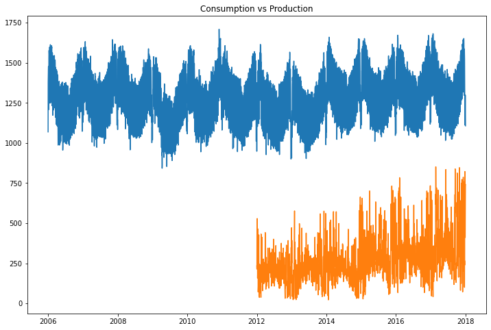

```python
## PLotting Coomsumption and production graph ##
plt.figure(figsize=(12,8))
plt.plot(df['Consumption'])
plt.plot(df['Wind+Solar'])
plt.title("Consumption vs Production")
plt.show()
```

### 1. Plotting and understanding a time series

Q1 - Plot the different time series. What do you understand, what do you notice ?

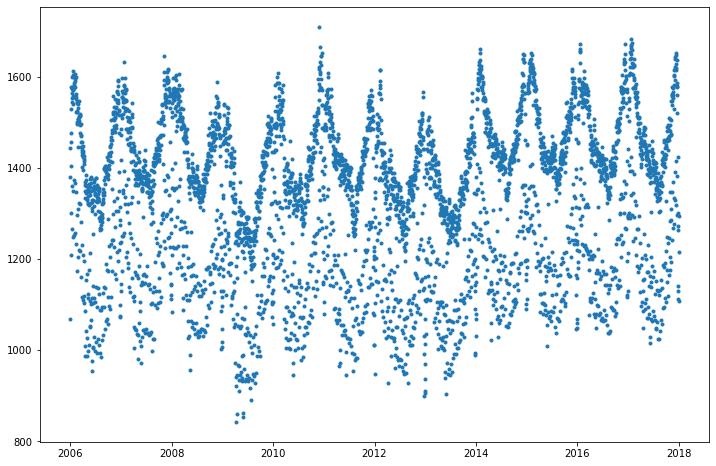

```python
## Creating a plot chart for years and consumption ##
plt.figure(figsize=(12,8))
plt.plot(df.index,df['Consumption'],linestyle="none",marker=".")
plt.show()
```

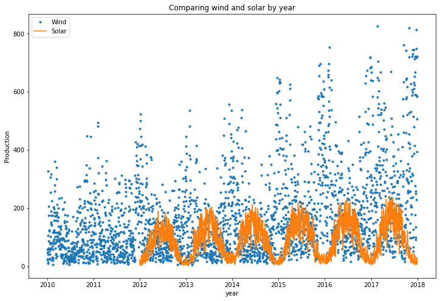

```python
## Creating a plot chart for years of solar and wind ##
plt.figure(figsize=(12,8))
plt.plot(df.index,df['Wind'],linestyle="none",marker=".")
plt.plot(df.index,df['Solar'])
plt.legend(['Wind', 'Solar'])
plt.title("Comparing wind and solar by year")
plt.xlabel("year")
plt.ylabel("Production")
plt.show()
```

What can we notice ?

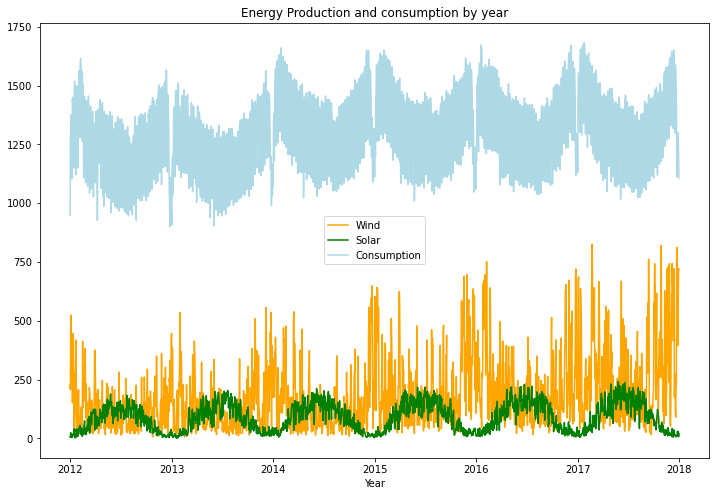

```python
## Plotting Wind, Solar and consumption graph. ##

plt.figure(figsize=(12,8))
plt.title("Energy Production and consumption by year")
plt.plot(df.loc['2012-01':"2017-12"].index, df['Wind'][(df.index.strftime('%Y-%m')  >= "2012-01") & (df.index.strftime('%Y-%m')  <= "2017-12")].values,c='orange')
plt.plot(df.loc['2012-01':"2017-12"].index, df['Solar'][(df.index.strftime('%Y-%m')  >= "2012-01") & (df.index.strftime('%Y-%m')  <= "2017-12")].values,c='g')
plt.plot(df.loc['2012-01':"2017-12"].index, df['Consumption'][(df.index.strftime('%Y-%m')  >= "2012-01") & (df.index.strftime('%Y-%m')  <= "2017-12")].values,c='lightblue')
plt.xlabel("Year")
plt.legend(["Wind","Solar","Consumption"])
plt.show()
```

How do consumption and production compare ?

- We notice that wind bsaed production increases over time, and is rather high in winter (for example more storms).
- On the other hand, the solar production is higher in summer (seems logic)
- The consumption is higher in winter

### 2. Change the scale

Q2 - Try to change the scale to understand the recurrent patterns !

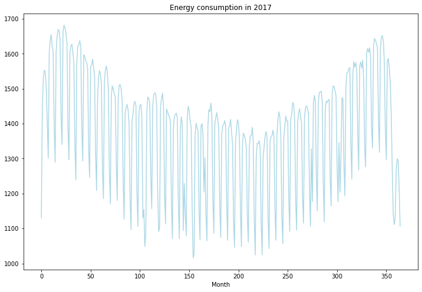

```python
## Plotting energy consumption in 2017 ##

plt.figure(figsize=(12,8))
plt.title("Energy consumption in 2017")
plt.xlabel("Month")
plt.plot(df['Consumption'][(df.index.strftime('%Y-%m') >= "2017-01") & (df.index.strftime('%Y-%m') <= "2017-12")].values,c='lightblue')
plt.show()
```

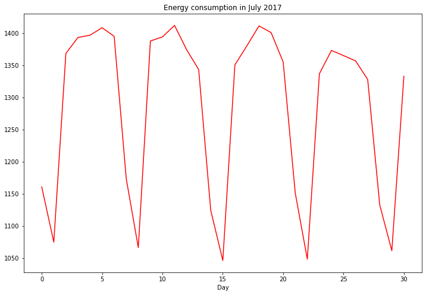

```python
## The plotting of energy consumption in July 2017 ##

plt.figure(figsize=(12,8))
plt.title("Energy consumption in July 2017")
plt.xlabel("Day")
plt.plot(df['Consumption'][(df.index.strftime('%Y-%m') >= "2017-07") & (df.index.strftime('%Y-%m') <= "2017-07")].values,c='r')
plt.show()
```

When zooming on a month, we oberve another seasonality. There seems to be days of the week in which people consume less. For example, here's what happens when we highlight Sundays :

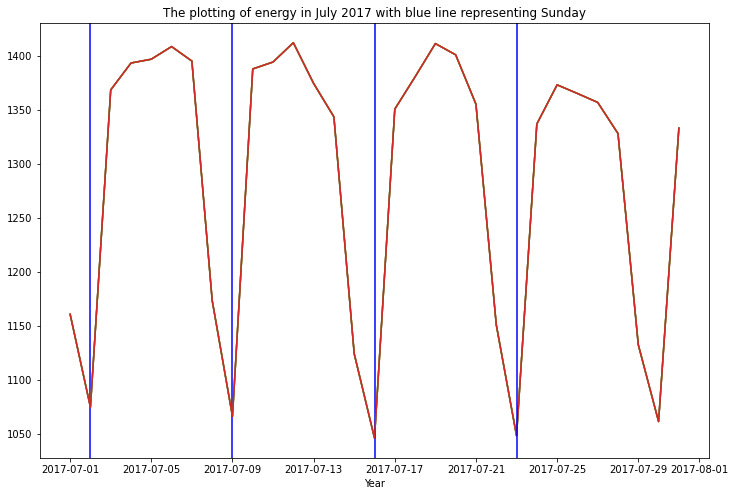

```python
## Plotting blue line on Sundays ##

plt.figure(figsize=(12,8))
for i in range(0,4):
    n = (i * 7) + 2
    plt.plot(df.loc["2017-07-01":"2017-07-31"]['Consumption'])
    plt.axvline(pd.to_datetime("2017-07-%d" % n),c="b")
plt.title("The plotting of energy in July 2017 with blue line representing Sunday")
plt.xlabel("Year")
plt.show()
```

### 3. Further exploration

Q3 - To further explore the dataset, we might need to group the data. Create new columns for the consumption (by year and month), and create box-plots with seaborn. Comment on your results.

```python
## The creation of new columns by 'year' and 'month' ##

df_2 = df.reset_index()
df_2['year'] = [d.year for d in df_2.Date]
df_2['month'] = [d.strftime("%b") for d in df_2.Date]
years = df_2['year'].unique()
df_2.head()
```

|  | Date | Consumption | Wind | Solar | Wind+Solar | year | month |
| --- | --- | --- | --- | --- | --- | --- | --- |
| 0 | 2006-01-01 | 1069.184 | NaN | NaN | NaN | 2006 | Jan |
| 1 | 2006-01-02 | 1380.521 | NaN | NaN | NaN | 2006 | Jan |
| 2 | 2006-01-03 | 1442.533 | NaN | NaN | NaN | 2006 | Jan |
| 3 | 2006-01-04 | 1457.217 | NaN | NaN | NaN | 2006 | Jan |
| 4 | 2006-01-05 | 1477.131 | NaN | NaN | NaN | 2006 | Jan |

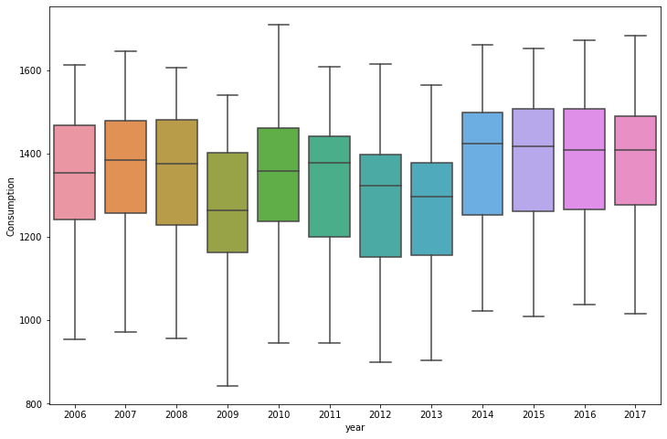

```python
## The Boxploting of years ##
import seaborn as sns
plt.figure(figsize=(12,8))
sns.boxplot(x="year",y="Consumption",data=df_2)
plt.show()
```

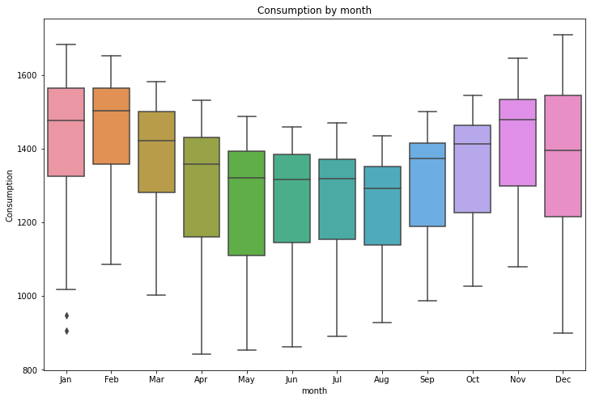

```python
## The plotting of a Boxplot by month ##
plt.figure(figsize=(12,8))
plt.title("Consumption by month")
sns.boxplot(x="month",y="Consumption",data=df_2)
#sns.boxplot(df.loc['2017-01':"2017-12"].index, df['Consumption'][(df.index.strftime('%Y-%m')  >= "2012-01") & (df.index.strftime('%Y-%m')  <= "2017-12")].values,data=df_2)
plt.show()
```

### 4. Fill missing values

Q4 - Do you face missing values in production ? If yes, which method can you apply ? What happens if you plot the modified data ? It is a good idea to keep the data this way ?

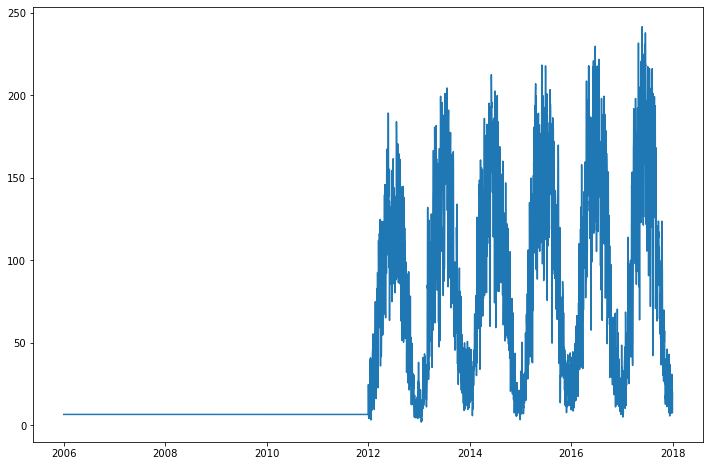

```python
## The plotting of solar Plot Solar ##
plt.figure(figsize=(12,8))
plt.plot(df['Solar'].bfill(axis=0))
plt.show()
```

The forward and backward fill are useful when some values are missing within the data, not when we miss years of data. This is a clear illustration.

### 5. Series correlation

Q5 - A good way to explore time series, when you have several series, is to plot one series vs another. This is a good way to estimate the correlation between 2 series. Plot the relevant graphs (and compute the correlation) for wind + solar vs consumption, wind vs solar, wind vs consumption, and solar vs consumption.

```python
## Correlation between consumption and overall production ##
df['Consumption']['2012-01-01':].corr(df['Wind+Solar']['2012-01-01':])
```

```
0.027647843859240934
```

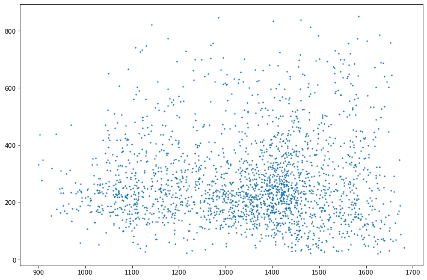

```python
## Plotting the correlation between Consumption and production ##
plt.figure(figsize=(12,8))
plt.scatter(df['Consumption']['2012-01-01':],df['Wind+Solar']['2012-01-01':], s=2)
plt.show()
```

```python
## The Correlation between consumption and wind production ##
df['Consumption']['2012-01-01':].corr(df['Wind']['2012-01-01':])
```

```
0.13518640075918514
```

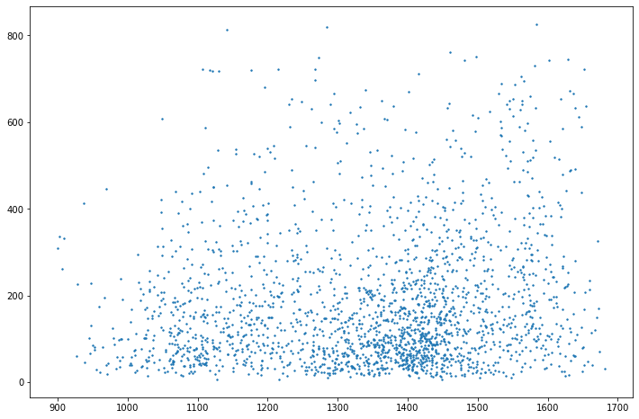

```python
## Plotting the correlation between Consumption and wind ##
plt.figure(figsize=(12,8))
plt.scatter(df['Consumption']['2012-01-01':],df['Wind']['2012-01-01':], s=2)
plt.show()
```

```python
## Correlation between Wind and solar production ##
df['Solar']['2012-01-01':].corr(df['Wind']['2012-01-01':])
```

```
-0.3088318295977341
```

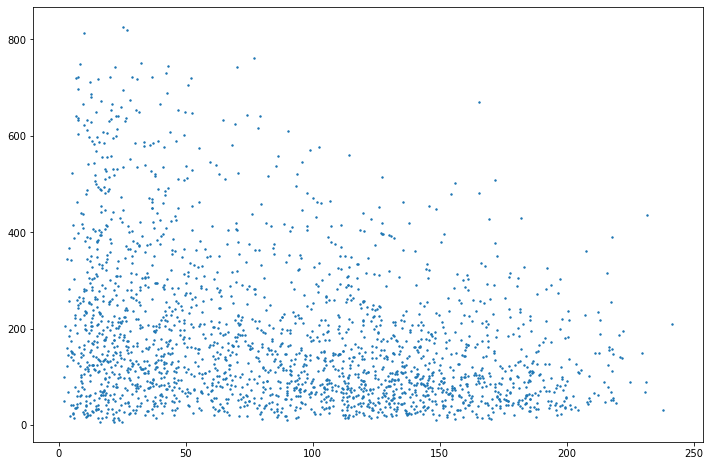

```python
## Plotting the correlation between solar and wind ##
plt.figure(figsize=(12,8))
plt.scatter(df['Solar']['2012-01-01':],df['Wind']['2012-01-01':], s=2)
plt.show()
```

```python
## Correlation between consumption and solar ##
df['Consumption']['2012-01-01':].corr(df['Solar']['2012-01-01':])
```

```
-0.27894265519914385
```

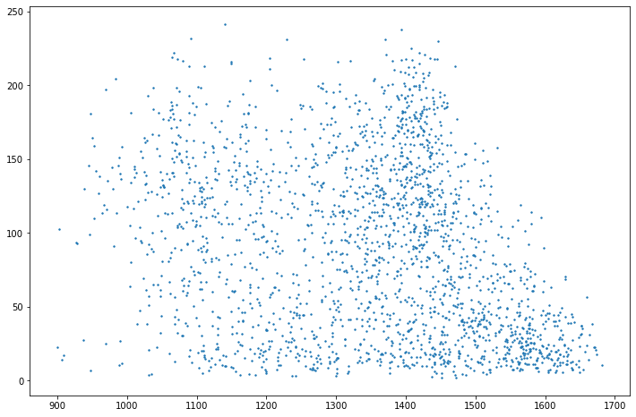

```python
## Plotting the correlation between solar and Consumption ##
plt.figure(figsize=(12,8))
plt.scatter(df['Consumption']['2012-01-01':],df['Solar']['2012-01-01':], s=2)
plt.show()
```